# ATAClone multiome demonstration

## Setup

### Load libraries

#### Code

```r
library("ATAClone")
library("MatrixGenerics")
library("ggplot2")
```

### Load datasets

Loads ATAC and RNA data for the chosen dataset (installed with the package), as well as a normal reference ATAC dataset and other reference files.

ATAC data is a matrix of genomic bin counts (rows) per cell (columns). “Stable” count matrices are computed by retaining only ATAC-seq fragments overlapping stably accessible regions, then computing bin counts. Matrices computed using all ATAC-seq fragments are also loaded here.

RNA data is a matrix of gene counts (rows) per cell (columns). Intron and exon count matrices are computed using only reads mapping to intronic and exonic regions respectively, as determined by the molecule_info file output by Cell Ranger.

#### Parameters

```r
assay_type <- "scMultiome"
#options:
#10X_Human_Kidney_Cancer_Chromium_Nuclei_Isolation
#10X_Human_Kidney_Cancer_CT_unsorted
#10X_Human_Kidney_Cancer_CT_sorted
#10X_Human_Kidney_Cancer_SaltyEZ
dataset <- "10X_Human_Kidney_Cancer_Chromium_Nuclei_Isolation"
```

#### Code

```r
dataset_path <- paste0(find.package("ATAClone", quiet = TRUE), "/extdata/", assay_type, "/", dataset)

#get paths for ATAC-related count matrices
stable_path <- paste0(dataset_path, "/ATAC/stable")
all_path <- paste0(dataset_path, "/ATAC/all")

#get paths for RNA-related count matrices
intron_path <- paste0(dataset_path, "/RNA/intron")
exon_path <- paste0(dataset_path, "/RNA/exon")
gex_path <- paste0(dataset_path, "/RNA/gex")

#load ATAC-related matrices
stable_counts <- read_matrix(stable_path)
all_counts <- read_matrix(all_path)

#load RNA-related matrices
intron_counts <- read_matrix(intron_path)
exon_counts <- read_matrix(exon_path)
gex_counts <- read_matrix(gex_path)

#Get barcodes with > 0 counts in both the ATAC and GEX assays
shared_barcodes <- intersect(colnames(stable_counts), colnames(intron_counts))

#load precomputed barcode probabilities
data("barcode_probabilities")

#get paths for normal reference ATAC-related count matrices
ref_path <- paste0(find.package("ATAClone", quiet = TRUE), "/extdata/", assay_type, "/", "10X_Human_Jejunum_Chromium_Nuclei_Isolation")

ref_stable_path <- paste0(ref_path, "/ATAC/stable")
ref_all_path <- paste0(ref_path, "/ATAC/stable")

#load normal reference ATAC-related matrices
stable_counts_ref <- read_matrix(ref_stable_path)
stable_counts_ref <- stable_counts_ref[,colSums(stable_counts_ref) > 1000]
all_counts_ref <- read_matrix(ref_all_path)
```

## Quality control

### Compute quality control statistics

Computes various quality control statistics for the 10X multiome assay. These will be covered in more detail in the code blocks below.

#### Code

```r
atac_stable_total <-  colSums(stable_counts)[shared_barcodes]
atac_all_total <-  colSums(all_counts)[shared_barcodes]
rna_intron_total <- colSums(intron_counts)[shared_barcodes]
barcode_odds <- 735320 * barcode.probs[shared_barcodes]
observed_non_zeros <- colSums(stable_counts[,shared_barcodes] != 0)
expected_non_zeros <- get_expected_non_zeros(stable_counts[,shared_barcodes], 0.015)
non_zero_residual <- observed_non_zeros - expected_non_zeros
stable_frac <- colSums(stable_counts)[shared_barcodes] / colSums(all_counts)[shared_barcodes]

qc_df <- data.frame(atac_stable_total,
                    atac_all_total,
                    rna_intron_total,
                    barcode_odds,
                    observed_non_zeros,
                    expected_non_zeros,
                    non_zero_residual,
                    stable_frac
)
```

### “Library size” filtering

Droplets containing intact cells (or nuclei in this case) are easily distinguished from background empty droplets/debris based on their DNA (from ATAC-seq) and RNA (from RNA-seq) content.

As we are working with nuclei here, we compute total RNA counts from only the intronic regions as these are generally only present in nuclear RNA and are not present in background cytoplasmic debris.

ATAC-seq counts are computed from only the “stably-accessible” regions because, as we will see later, total ATAC-seq counts vary technically.

#### Parameters

```r
min_stable_total <- 300
min_intron_total <- 300
```

#### Code

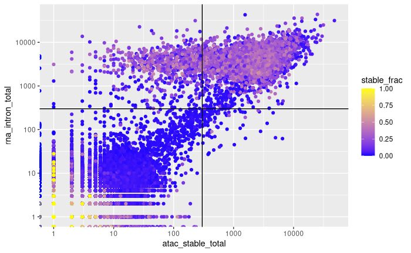

```r
ggplot(qc_df, aes(x = atac_stable_total, y = rna_intron_total, color = stable_frac)) + geom_point() +
  scale_x_log10() + scale_y_log10() + scale_color_gradient(low = "blue", high = "yellow") +
  geom_vline(xintercept = min_stable_total) + geom_hline(yintercept = min_intron_total)
```

### “Barcode odds” filtering

In the 10X multiome assay, some cell barcode sequences have a lower probability of being detected on the ATAC-seq side (having > 0 ATAC-seq fragments). If they appear, they also have lower than expected ATAC-seq fragment counts.

ATAClone includes a pre-computed estimate of each “barcode probability” - the probability that a cell barcode will be detected. The “barcode odds” are the ratio of these probabilities to a probability under the assumption of equal likelihood (i.e. 1 / 735320).

#### Parameters

```r
min_barcode_odds <- 1
```

#### Code

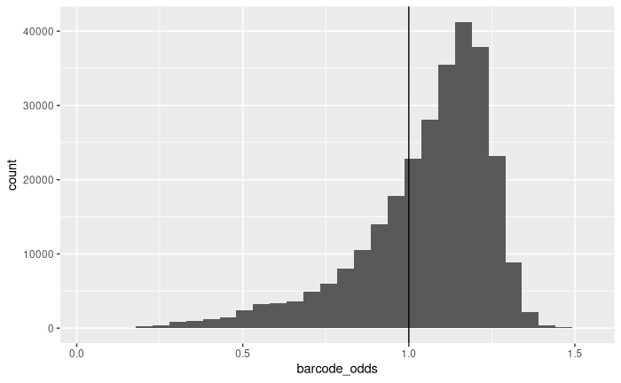

```r
ggplot(qc_df, aes(x = barcode_odds)) + geom_histogram() + geom_vline(xintercept = min_barcode_odds)
```

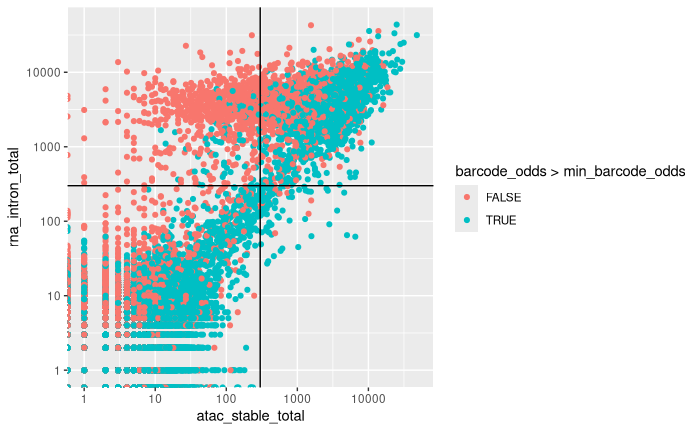

```r
ggplot(qc_df, aes(x = atac_stable_total, y = rna_intron_total, color = barcode_odds > min_barcode_odds)) + geom_point() +
  scale_x_log10() + scale_y_log10() + geom_vline(xintercept = min_stable_total) +
  geom_hline(yintercept = min_intron_total)
```

### Debris filtering

Single-cell assays generally contain some cell/nuclear debris. In the 10X multiome assay, these can be detected visually as the droplets with simultaneously lower DNA and RNA counts. They are easily detected automatically by the number of zero counts they contain across their genomic bins. That these droplets also contain low fractions of reads in stably-accessible regions (a subset of all peak regions) suggests that this debris may be generated by apoptosis where chromatin condensation is a hallmark.

#### Parameters

```r
#the minimum difference between the observed and expected number of non-zero bin counts to be retained
min_non_zero_residual <- -12
```

#### Code

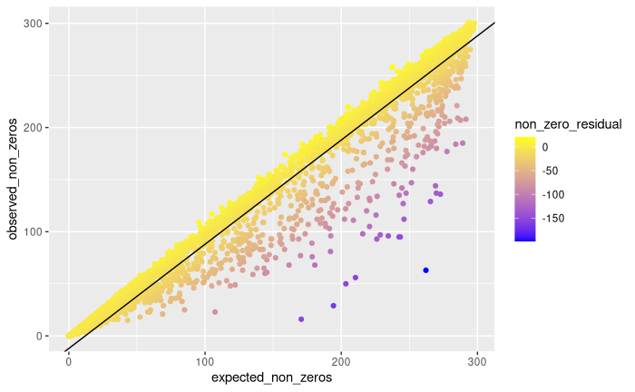

```r
ggplot(qc_df, aes(x = expected_non_zeros, y = observed_non_zeros, color = non_zero_residual)) + geom_point() +
  scale_color_gradient(low = "blue", high = "yellow") + geom_abline(intercept = min_non_zero_residual, slope = 1)
```

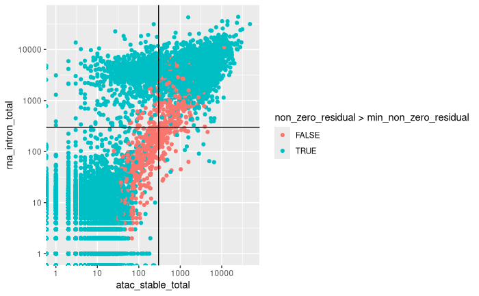

```r
ggplot(qc_df, aes(x = atac_stable_total, y = rna_intron_total, color = non_zero_residual > min_non_zero_residual)) + geom_point() +
  scale_x_log10() + scale_y_log10() + geom_vline(xintercept = min_stable_total) +
  geom_hline(yintercept = min_intron_total)
```

### Stable fraction filtering

We know from bulk ATAC-seq experiments that increasing the concentration of transposase or the exposure time to transposase increases the fraction of ATAC-seq fragments mapping to peak regions. This needs to be corrected when comparing different bulk ATAC-seq experiments. Likewise, different droplets in a single-cell experiment have different transposition efficiencies and contain different fractions of ATAC-seq fragments mapping to peak regions (the fraction of counts in stably-accessible regions is a proxy for this). Note that when using all ATAC-seq fragments, total DNA decreases as the transposition efficiency increases (see the plot below).

Computing bin counts from stably-accessible regions is generally sufficient to remove most transposition efficiency bias (we will revisit this below). However, droplets with a low transposition efficiency (low stable fraction) sometimes look artificially different and can be removed.

This is OPTIONAL. In some cases, it can remove cell types of interest. It is also possible to correct this effect downstream at the PCA step. If intending to filter by stable fraction, a reasonable starting point might be the minimum fraction to exclude nuclear debris, measured as before by low non-zero counts.

#### Parameters

```r
min_stable_frac <- 0.05
```

#### Code

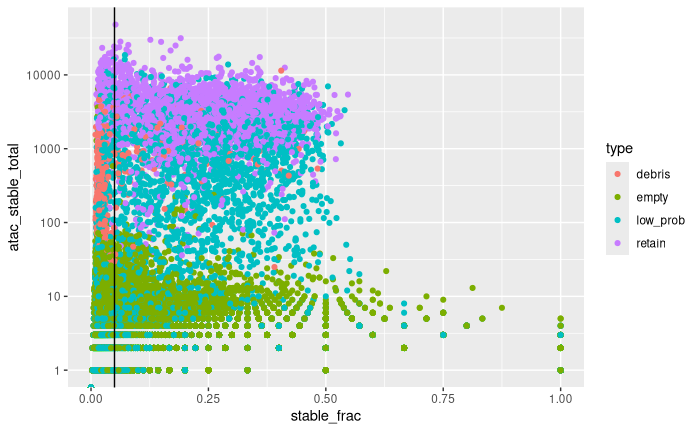

```r
qc_df$type <- rep("retain", length(shared_barcodes))
qc_df$type[qc_df$rna_intron_total < min_intron_total] <- "empty"
qc_df$type[non_zero_residual < min_non_zero_residual] <- "debris"
qc_df$type[qc_df$barcode_odds < min_barcode_odds] <- "low_prob"

ggplot(qc_df, aes(x = stable_frac, y = atac_stable_total, color = type)) + geom_point() + scale_y_log10() + geom_vline(xintercept = min_stable_frac)
```

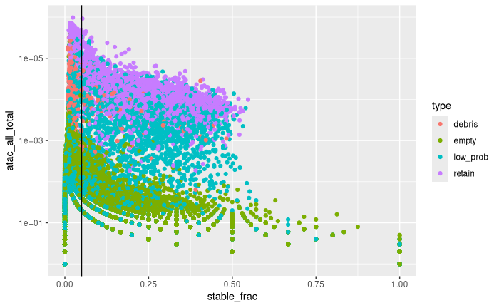

```r
ggplot(qc_df, aes(x = stable_frac, y = atac_all_total, color = type)) + geom_point() +
  scale_y_log10() + geom_vline(xintercept = min_stable_frac)
```

### Final filtering

We apply all of our filtering parameters here.

#### Code

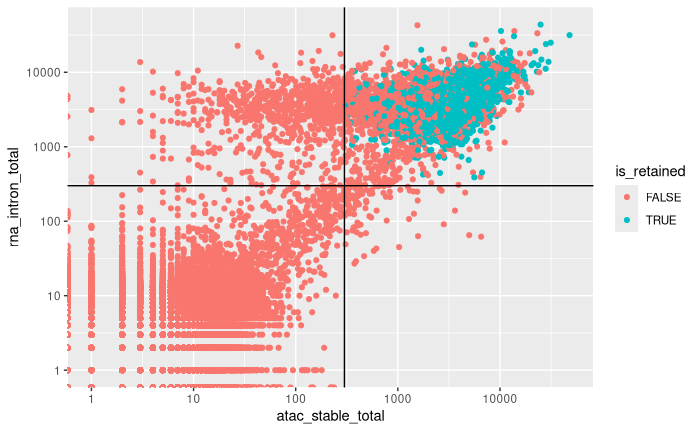

```r
is_retained <- colSums(stable_counts)[shared_barcodes] > min_stable_total &
  colSums(intron_counts)[shared_barcodes] > min_intron_total &
  barcode_odds > min_barcode_odds &
  non_zero_residual > min_non_zero_residual &
  stable_frac > min_stable_frac

ggplot(qc_df, aes(x = atac_stable_total, y = rna_intron_total, color = is_retained)) + geom_point() +
  scale_x_log10() + scale_y_log10() + geom_vline(xintercept = min_stable_total) +
  geom_hline(yintercept = min_intron_total)
```

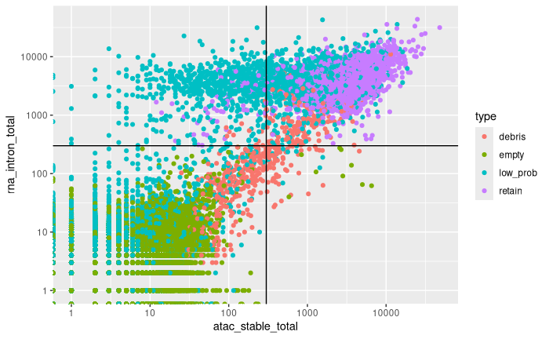

```r
ggplot(qc_df, aes(x = atac_stable_total, y = rna_intron_total, color = type)) + geom_point() +
  scale_x_log10() + scale_y_log10() + geom_vline(xintercept = min_stable_total) +
  geom_hline(yintercept = min_intron_total)
```

```r
retained_barcodes <- shared_barcodes[which(is_retained)]

#filter ATAC count matrices
stable_counts_filtered <- stable_counts[,retained_barcodes]
all_counts_filtered <- all_counts[,retained_barcodes]

#filter RNA count matrices
intron_counts_filtered <- intron_counts[, retained_barcodes]
exon_counts_filtered <- exon_counts[, retained_barcodes]
gex_counts_filtered <- gex_counts[, retained_barcodes]

#filter some QC metrics (we'll come back to them later)
stable_frac_filtered <- stable_frac[retained_barcodes]
atac_stable_total_filtered <- atac_stable_total[retained_barcodes]
atac_all_total_filtered <- atac_all_total[retained_barcodes]
```

### Aside: why use counts of stably-accesible regions?

As mentioned previously, there is technical variation in transposition efficiency across a single-cell experiment. This is mostly eliminated by only counting fragments overlapping stably-accessible regions. When counting all fragments, it introduces complex biases in the proportions of fragments mapping to different bins which are difficult to correct. We demonstrate this below by fitting Poisson regression of the proportion of each bin to the per-cell fraction of counts in stably-accessible regions. In general, bins containing higher fractions of reads mapping to stably-accessible regions increase in proportion as the transposition frequency increases, while bins containing lower fractions of reads mapping to stably-accesible regions decrease in proportion.

#### Code

```r
pred_frac_stable <- fit_stable_frac_regression(stable_counts_filtered, stable_counts_filtered, all_counts_filtered)
```

[output not shown]

```r
pred_frac_all <- fit_stable_frac_regression(all_counts_filtered, stable_counts_filtered, all_counts_filtered)
```

[output not shown]

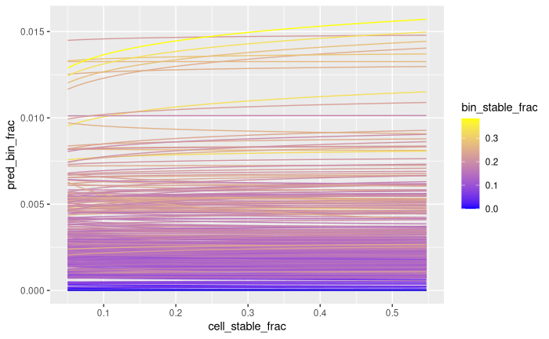

```r
ggplot(pred_frac_stable, aes(x = cell_stable_frac, y = pred_bin_frac, group = bin, color = bin_stable_frac)) + geom_line() + scale_color_gradient(low = "blue", high = "yellow")
```

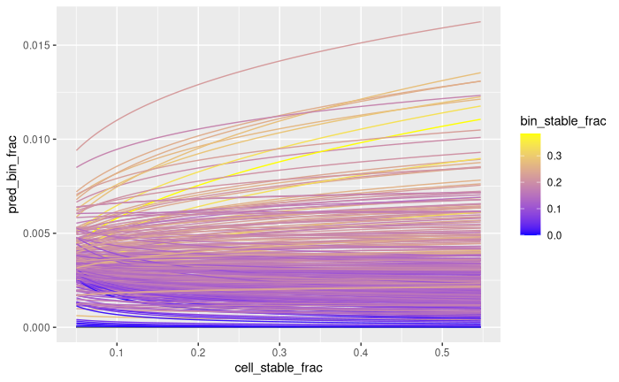

```r
ggplot(pred_frac_all, aes(x = cell_stable_frac, y = pred_bin_frac, group = bin, color = bin_stable_frac)) + geom_line() + scale_color_gradient(low = "blue", high = "yellow")
```

## Clone identification

### Normalisation

ATAClone adopts the position that variance-stabilising transformations have ideal properties for normalisation: by equalising random noise, features are weighted only by their variance *exceeding* random noise when finding a new representation by principal component analysis. These principal components may represent both biological factors of interest and unwanted technical variation.

After applying the variance-stabilising transformation and correcting for these principal components, we can verify whether the normalised data has stable variance based on whether it closely approximates simulated data after normalisation (drawn as the fitted line on the plot below).

#### Parameters

```r
nb_overdispersion <- 0.01
#the overdispersion parameter used to estimate lambda for a power function - can be set differently to nb_overdispersion
#Setting higher results in decreasing mean-variance trend - useful when technical factors confound clone separation
fit_nb_overdispersion <- 0.01
pseudo_count <- 0.5
lambda <- NULL
discard_pcs <- c(1,3)
npcs <- 25
```

#### Code

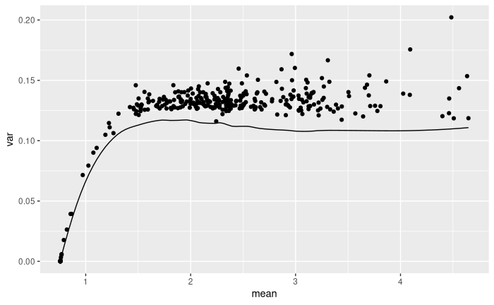

```r
#find lambda to normalise using power transformation instead of vst
lambda <- find_lambda(stable_counts_filtered, fit_nb_overdispersion, pseudo_count)
loess_mean_var <- fit_sim_mean_var(stable_counts_filtered, nb_overdispersion, pseudo_count, lambda)

stable_counts_filtered_norm <- normalise_counts(stable_counts_filtered, nb_overdispersion, pseudo_count, lambda)
stable_counts_filtered_norm_cor <- correct_normalised_counts(stable_counts_filtered_norm, discard_pcs)

norm_df <- data.frame(mean = rowMeans(stable_counts_filtered_norm_cor), var = rowVars(stable_counts_filtered_norm_cor))
ggplot(norm_df, aes(x = mean, y = var)) + geom_point() + stat_function(fun = function(x){predict(loess_mean_var, x)})
```

### PCA

We have already assumed a set of principal components represent unwanted technical variation in the previous section. Here we verify this selection by comparing to known scATAC-seq technical factors.

Because our normalisation method does not scale out “library size”, PC1 invariably corresponds to total DNA and should be discarded. In some cases, using stably-accessible regions is insufficient to remove the effect of transposition efficiency. When this occurs, it will be seen in the leading principal components as a PC correlating to the fraction of reads in stably-accessible regions. If there is no PC with a high correlation (say, > 0.4), then it may not be necessary to discard any PCs.

#### Code

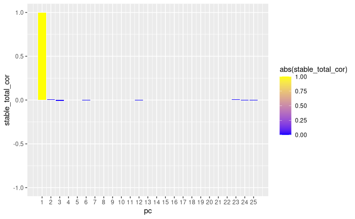

```r
#do a per-cell Poisson regression over its bins against each bin's stable fraction (or its expected counts) to find residual dependence on transposition efficiency
x <- log(rowMeans(stable_counts_ref)[rowMeans(stable_counts_ref) > 0])
y <- as.list(as.data.frame(as.matrix(stable_counts_filtered)[rowMeans(stable_counts_ref) > 0,]))
betas <- get_pois_regression_betas(y, x)

stable_counts_filtered_norm_pca <- get_pca(stable_counts_filtered_norm, npcs)

stable_total_cor <- cor(stable_counts_filtered_norm_pca$x, sqrt(atac_stable_total_filtered))[,1]
stable_frac_cor <- cor(stable_counts_filtered_norm_pca$x, betas)[,1]

pca_df <- data.frame(pc = 1:npcs, stable_total_cor, stable_frac_cor)
pca_df2 <- data.frame(stable_counts_filtered_norm_pca$x, sqrt_stable_total = sqrt(atac_stable_total_filtered), beta = betas)

ggplot(pca_df, aes(x = pc, y = stable_total_cor, fill = abs(stable_total_cor))) + geom_col() +
  ylim(c(-1,1)) + scale_x_continuous(breaks = 1:npcs) + scale_fill_gradient(low = "blue", high = "yellow", limits = c(0,1))
```

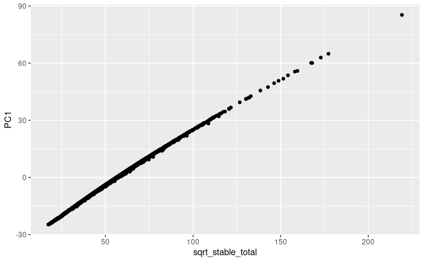

```r
best_pc <- paste0("PC", order(abs(pca_df$stable_total_cor), decreasing = T)[1])
ggplot(pca_df2, aes(x = sqrt_stable_total, y = get(best_pc))) + geom_point() + ylab(best_pc)
```

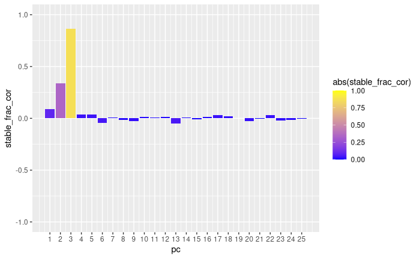

```r
ggplot(pca_df, aes(x = pc, y = stable_frac_cor, fill = abs(stable_frac_cor))) + geom_col() +
  ylim(c(-1,1)) + scale_x_continuous(breaks = 1:npcs) + scale_fill_gradient(low = "blue", high = "yellow", limits = c(0,1))
```

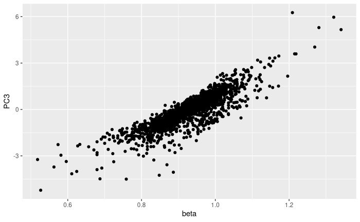

```r
best_pc2 <- paste0("PC", order(abs(pca_df$stable_frac_cor), decreasing = T)[1])
ggplot(pca_df2, aes(x = beta, y = get(best_pc2))) + geom_point() + ylab(best_pc2)
```

### Graph-based clustering

ATAClone identifies tumour clones based on graph-based clustering. Briefly, we build a KNN-graph based on the PCA embeddings we previously computed (excluding unwanted technical factors). Then, based on the mean-variance relationship we previously assumed, we simulate homogeneous count data, perform normalisation and dimensionality reduction, and build a second “null” KNN-graph. Using this “null” KNN-graph, we iterate over clustering resolution parameters until we find the highest resolution parameter within a user-specified “tolerance” (the proportion of cells not assigned to the largest cluster). We then use this resolution to perform graph-based clustering on the KNN graph of our original data. This procedure is then repeated recursively (by default, just one more time). For a more in-depth exploration of the clustering parameters, refer to the clustering vignette.

After deriving the clones, we verify that they are not explained by unwanted technical variation by visualising known technical factors on the UMAP representation of the data. We will verify that each “clone” is explained by copy number differences in the next section.

#### Parameters

```r
knn_k <- 20
```

#### Code

```r
leiden_clusters <- iterative_cluster_sim(stable_counts_filtered, nb_overdispersion, pseudo_count, lambda, npcs, discard_pcs, knn_k, tolerance = 0.05, start = 0)
```

```
[1] "Beginning clustering iteration 1"
[1] "Finding resolution for simulated cluster start"
[1] "Beginning binary search"
[1] "Tried resolution 20 (p=0.3118)"
[1] "Tried resolution 10 (p=0)"
[1] "Tried resolution 15 (p=0)"
[1] "Tried resolution 17.5 (p=0)"
[1] "Tried resolution 18.75 (p=0.0399)"
[1] "Tried resolution 19.375 (p=0.2046)"
[1] "Tried resolution 19.0625 (p=0.0939)"
[1] "Tried resolution 18.90625 (p=0.0605)"
[1] "Tried resolution 18.828125 (p=0.0572)"
[1] "Tried resolution 18.7890625 (p=0.0506)"
[1] "Found 3 clusters"
[1] "Beginning clustering iteration 2"
```

[output cut: 29 more lines]

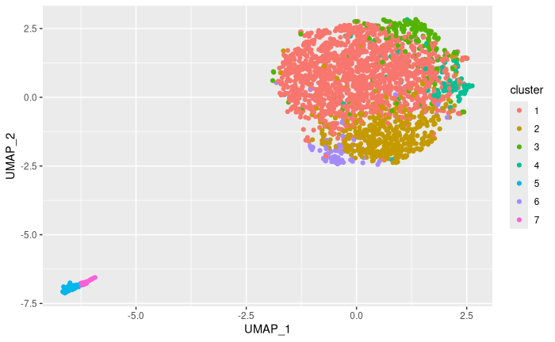

```r
umap_embeddings <- get_umap(stable_counts_filtered_norm_pca$x, npcs, discard_pcs)
cluster_outliers <- get_cluster_outliers(stable_counts_filtered_norm_pca$x, leiden_clusters, npcs, discard_pcs, knn_k, 0.2)

cluster_df <- data.frame(umap_embeddings, cluster = leiden_clusters, stable_total = atac_stable_total_filtered, stable_frac = stable_frac_filtered, is_outlier = cluster_outliers, beta = betas)
ggplot(cluster_df, aes(x = UMAP_1, y= UMAP_2, color = cluster)) + geom_point()
```

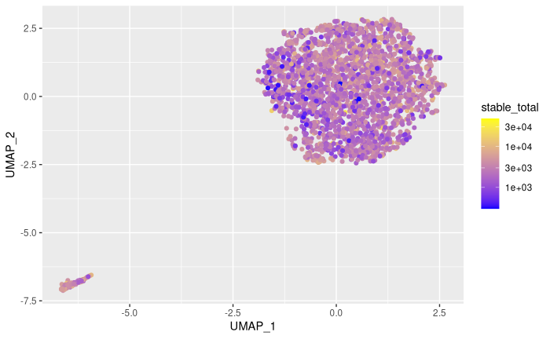

```r
ggplot(cluster_df, aes(x = UMAP_1, y= UMAP_2, color = stable_total)) + geom_point() + scale_color_gradient(low = "blue", high = "yellow", trans = "log10")
```

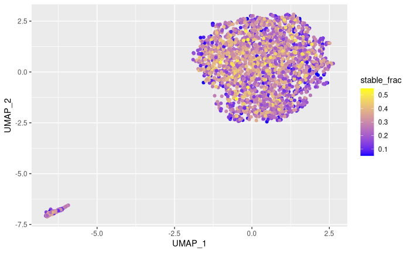

```r
ggplot(cluster_df, aes(x = UMAP_1, y= UMAP_2, color = stable_frac)) + geom_point() + scale_color_gradient(low = "blue", high = "yellow")
```

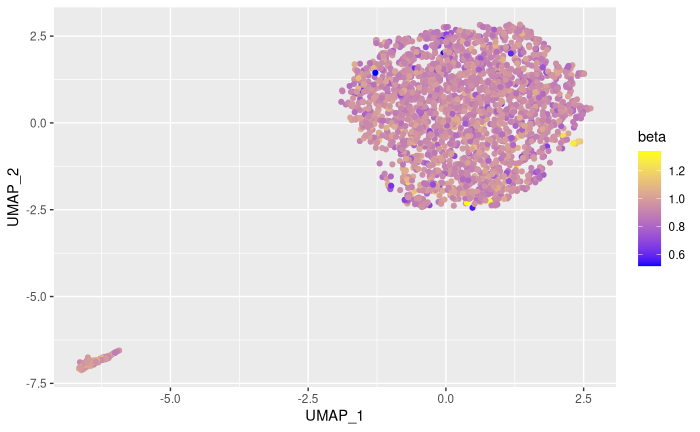

```r
ggplot(cluster_df, aes(x = UMAP_1, y= UMAP_2, color = beta)) + geom_point() + scale_color_gradient(low = "blue", high = "yellow")
```

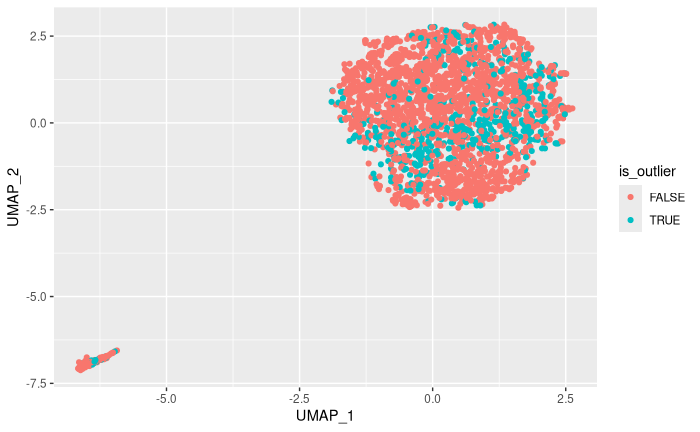

```r
ggplot(cluster_df, aes(x = UMAP_1, y= UMAP_2, color = is_outlier)) + geom_point()
```

### Copy number visualisation

To verify that tumour “clones” have genuine copy number differences, we estimate and visualise copy number. Here, copy number is estimated based on an external non-tumour reference. Clusters are sorted based on hierarchical clustering of the average of their copy number estimates; within each cluster, cells are sorted by hierarchical clustering of their PCA embeddings to help visually detect additional sub-cluster copy number variants. Non-tumour cells appear as clusters of cells with relatively uniform copy number profiles.

Importantly, the copy number estimates visualised here are only “relative” as opposed to “absolute”. That is, copy number is scaled to be approximately diploid on average, even if a tumour is polyploid on average. Later sections investigate obtaining absolute copy number estimates.

#### Code

[output not shown]

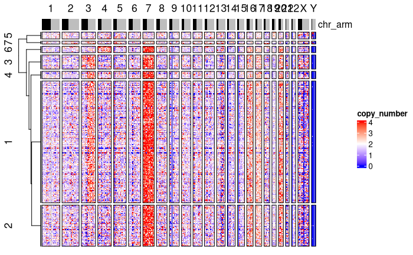

```r
stable_counts_ref <- stable_counts_ref[,colSums(stable_counts_ref) > 1000]
plot_copy_number(stable_counts_filtered, stable_counts_ref, leiden_clusters, stable_counts_filtered_norm_pca, discard_pcs, is_ref_female = T)
```

## Downstream Analysis

### Doublet detection

After accounting for “low probability” barcodes, it is clear that total RNA and total DNA (as measured by ATAC-seq) are positively correlated. One explanation for this is the occurrence of doublets/multiplets in droplet-based single-cell sequencing.

Here, we will use scDblFinder to help find doublets. As we have already performed extensive filtering, scDblFinder’s doublet rate estimate is likely to be underestimated, increasing the doublet score threshold required for doublet classification. We will choose our own threshold here as the value which separates barcodes with high intronic RNA counts from barcodes with low intronic RNA counts. As the score is based in part on total ATAC stable counts, this can help reduce overfitting.

#### Parameters

```r
min_scdbl_score <- 0.6
#scDblFinder appears to be quite stochastic - set a seed
use.seed <- 100
```

#### Code

```r
set.seed(use.seed)
scdbl_out <- scDblFinder::scDblFinder(stable_counts_filtered, clusters = leiden_clusters, dims = npcs,
                                     processing = scDblFinder_custom_function, dbr = 0.025 * ncol(stable_counts_filtered) / 1000, nrounds = 1)
```

[output not shown]

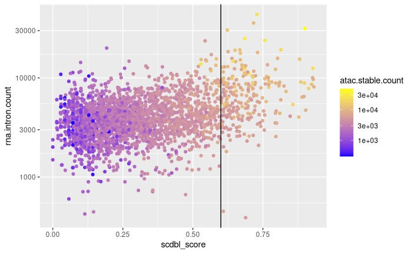

```r
scdbl_df <- data.frame(atac.stable.count = colSums(stable_counts_filtered),
                       rna.intron.count = colSums(intron_counts_filtered),
                       scdbl_score = scdbl_out$scDblFinder.score)
ggplot(scdbl_df, aes(x = scdbl_score, y = rna.intron.count, color = atac.stable.count)) + geom_point() + scale_color_gradient(low = "blue", high = "yellow", trans = "log10") + scale_y_log10() + geom_vline(xintercept = min_scdbl_score)
```

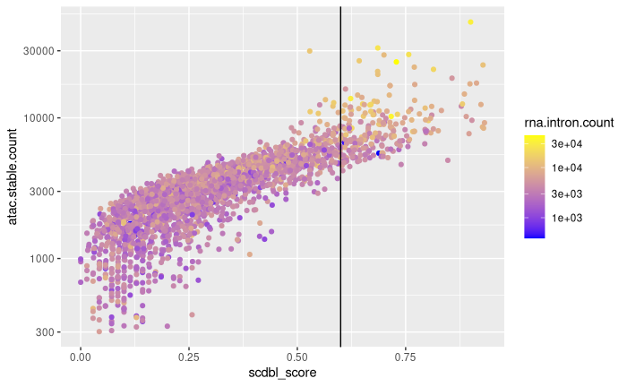

```r
ggplot(scdbl_df, aes(x = scdbl_score, y = atac.stable.count, color = rna.intron.count)) + geom_point() + scale_color_gradient(low = "blue", high = "yellow", trans = "log10") + scale_y_log10() + geom_vline(xintercept = min_scdbl_score)
```

### Removing doublets

Rather than use our thresholded calls directly, we will use them to find a second threshold on the total stable counts per barcode. This is done by considering the thresholded calls to be the ground truth, then finding a total stable counts threshold which maximises the F1 score. The advantage of this approach is that it allows identification of “homotypic” doublets consisting of two cells of the same type, and also reduces the influence of any undetected doublets on copy number/ploidy calls. However, if an experiment contains genuine mixtures of cells of different ploidies, then these high-ploidy cells would also be removed.

#### Code

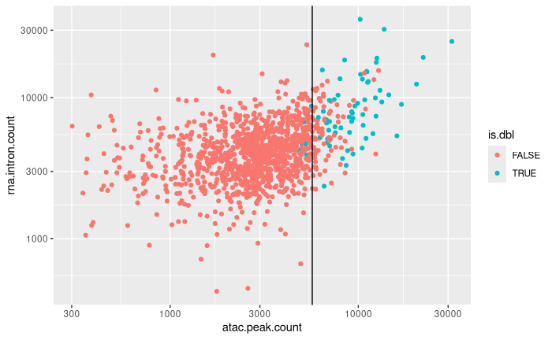

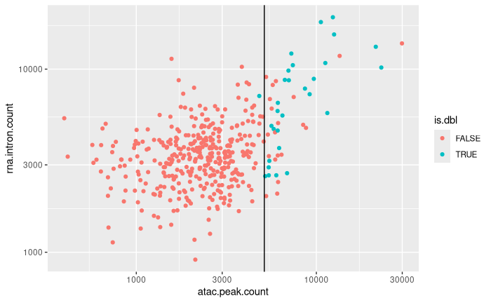

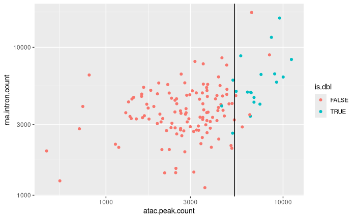

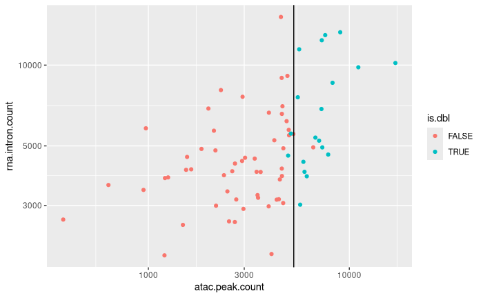

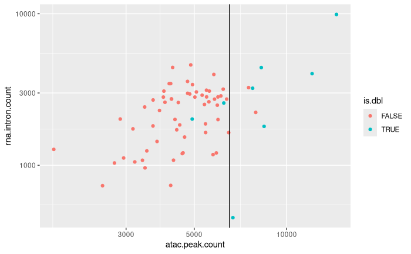

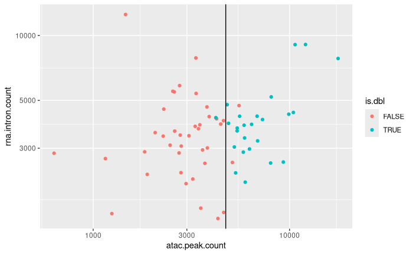

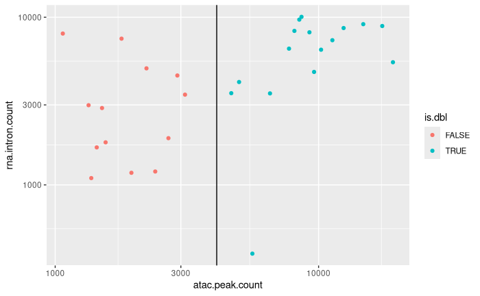

```r
doublet_thresholds <- get_doublet_thresholds(stable_counts_filtered, leiden_clusters, scdbl_out$scDblFinder.score > min_scdbl_score)
scdblFinder_class <- scdbl_out$scDblFinder.score > min_scdbl_score
is_doublet <- logical(length(leiden_clusters))
for (i in levels(leiden_clusters)){
  is_doublet[leiden_clusters == i] <- colSums(stable_counts_filtered[,leiden_clusters == i]) > doublet_thresholds[as.integer(i)]
  doublet_df <- data.frame(atac.peak.count = colSums(stable_counts_filtered[,leiden_clusters == i & !cluster_outliers]),
                           rna.intron.count = colSums(intron_counts_filtered[,leiden_clusters == i & !cluster_outliers]),
                           is.doublet = is_doublet[leiden_clusters == i & !cluster_outliers],
                           is.dbl = scdblFinder_class[leiden_clusters == i & !cluster_outliers]
  )
  plot(ggplot(doublet_df, aes(x = atac.peak.count, y = rna.intron.count, color = is.dbl)) + geom_point() + scale_x_log10() + scale_y_log10() + geom_vline(xintercept = doublet_thresholds[as.integer(i)]))
}
```

### Absolute copy number estimation

Given the correlation between total RNA and total DNA (as measured by ATAC-seq), we might also assume that we can estimate copy number absolutely by using the non-tumour cells from the same experiment as our normal reference. Estimates may be confounded if the normal reference cells are polyploid. However, this is generally thought to be rare.

#### Parameters

```r
ref_cluster <- 5
exclude_clusters <- c(7)
y_lim <- c(0,6)
sf_start <- 0.7
sf_stop <- 2.4
sf_step <- 0.05
```

#### Code

```r
is_excluded <- cluster_outliers | is_doublet | leiden_clusters %in% exclude_clusters
cn_fit_out <- ATAClone:::fit_cn_clusters(stable_counts_filtered, leiden_clusters, 5, F, is_excluded, 1000, sf_start, sf_stop, sf_step, T, T)
```

```
[1] "Fitting 5 clusters individually"
[1] "Fitting cluster 1 (1/5)"
[1] "Fitting cluster 2 (2/5)"
[1] "Fitting cluster 3 (3/5)"
[1] "Fitting cluster 4 (4/5)"
[1] "Fitting cluster 6 (5/5)"
[1] "Fitting 10 cluster pairs"
[1] "Fitting cluster 2 to cluster 1 (1/10)"
[1] "Fitting cluster 3 to cluster 1 (2/10)"
[1] "Fitting cluster 4 to cluster 1 (3/10)"
[1] "Fitting cluster 6 to cluster 1 (4/10)"
[1] "Fitting cluster 3 to cluster 2 (5/10)"
[1] "Fitting cluster 4 to cluster 2 (6/10)"
[1] "Fitting cluster 6 to cluster 2 (7/10)"
[1] "Fitting cluster 4 to cluster 3 (8/10)"
[1] "Fitting cluster 6 to cluster 3 (9/10)"
[1] "Fitting cluster 6 to cluster 4 (10/10)"
```

```r
absolute_cn_list <- get_absolute_copy_number(stable_counts_filtered, leiden_clusters, 5, cn_fit_out$scale_factors, is_excluded, F)
```

[output not shown]

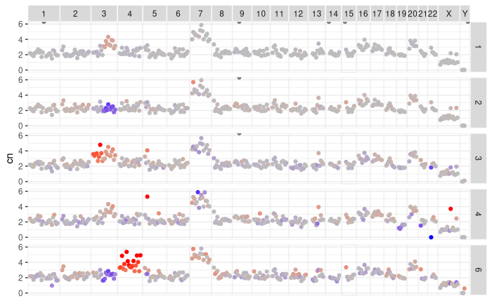

```r
#for (i in seq_along(absolute_cn_list)){
#  plot_absolute_cn(absolute_cn_list[[i]], names(absolute_cn_list)[i])
#}
plot_absolute_cn2(absolute_cn_list, y_lim = y_lim, exclude_clusters = c("all",exclude_clusters))
```